# Screening and Cleaning Flanker Task

## Overview

This R Markdown script is intended to be developed for preprocessing data from the Flanker task collected as part of the PD Executive Inhibition dataset. Click Knit HTML in Rstudio to build the document.

Some code coding practices:

- For data-related decisions, put your initials and the date
- Abstract large chunks of code to separate function files (e.g., `rt_functions.R`)
- Make use of Github to track milestones (this folder is already a [repository](https://github.com/PennStateDEPENdLab/PD_Inhibition_DDM)
- Organize document into sections using headers

## Description of task

These are data from an Eriksen-style flanker task, in which participants must push a button denoting the facing of a central arrow (left or right) while ignoring flanking arrows. Incongruent trials have a mismatch between the central and flanking stimuli, whereas congruent trials match. This version was adapted from Casey et al. 2000, where there were mostly incongruent (70%) blocks and mostly congruent (70%) blocks.

Participants completed 160 trials of the flanker in four blocks of forty trials in ABBA order, where A is mostly congruent and B is mostly incongruent. Flanker stimuli were displayed for 1000ms with a 500ms ITI. Across all blocks the frequency of incongruent stimuli was 50%.

## Details of screening and cleaning data

Original data are stored in Data/SAS Originals/flanker.sas7bdat. Data can be loaded into R using the sas7bdat package, but are imported into a `.RData` object called `flanker`. This is loaded here before proceeding.

The basic structure of the raw data is as follows:

```r
str(flanker, give.attr=FALSE)
```

```
## Classes 'tbl_df', 'tbl' and 'data.frame':    17760 obs. of  27 variables:
##  $ Subject                 : num  1 1 1 1 1 1 1 1 1 1 ...
##  $ Clock_StartTimeOfDay    : num  17570 17570 17570 17570 17570 ...
##  $ SessionDate             : num  17570 17570 17570 17570 17570 ...
##  $ SessionTime             : num  40541 40541 40541 40541 40541 ...
##  $ Block                   : num  9 10 11 12 13 14 15 16 17 18 ...
##  $ Central                 : Factor w/ 2 levels "L","R": 2 1 2 1 2 2 1 2 1 2 ...
##  $ CongruentTrials         : num  3 2 3 1 4 3 1 3 2 4 ...
##  $ CongruentTrials_Cycle   : num  1 1 1 1 1 1 1 1 1 1 ...
##  $ CongruentTrials_Sample  : num  1 2 3 4 5 6 7 8 9 10 ...
##  $ Correct                 : Factor w/ 2 levels "f","j": 2 1 2 1 2 2 1 2 1 2 ...
##  $ Flanker                 : Factor w/ 2 levels "L","R": 2 2 2 1 1 2 1 2 2 1 ...
##  $ IncongruentTrials       : num  NaN NaN NaN NaN NaN NaN NaN NaN NaN NaN ...
##  $ IncongruentTrials_Cycle : num  NaN NaN NaN NaN NaN NaN NaN NaN NaN NaN ...
##  $ IncongruentTrials_Sample: num  NaN NaN NaN NaN NaN NaN NaN NaN NaN NaN ...
##  $ Procedure               : Factor w/ 2 levels "CongruentProc",..: 1 1 1 1 1 1 1 1 1 1 ...
##  $ Running                 : Factor w/ 2 levels "CongruentTrials",..: 1 1 1 1 1 1 1 1 1 1 ...
##  $ TrialSlide_ACC          : num  1 1 1 1 1 1 1 1 1 1 ...
##  $ TrialSlide_CRESP        : Factor w/ 3 levels "","f","j": 3 2 3 2 3 3 2 3 2 3 ...
##  $ TrialSlide_DurationError: num  0 0 0 0 0 0 0 0 0 0 ...
##  $ TrialSlide_OnsetDelay   : num  0 0 0 0 0 0 0 0 0 0 ...
##  $ TrialSlide_OnsetTime    : num  60071 61577 63083 64590 66096 ...
##  $ TrialSlide_RESP         : Factor w/ 3 levels "","f","j": 3 2 3 2 3 3 2 3 2 3 ...
##  $ TrialSlide_RT           : num  537 599 397 450 376 413 403 377 439 445 ...
##  $ TrialSlide_RTTime       : num  60608 62176 63480 65040 66472 ...
##  $ Incongruent             : num  0 1 0 0 1 0 0 0 1 1 ...
##  $ computer                : num  0 0 0 0 0 0 0 0 0 0 ...
##  $ CongruentBlock          : num  1 1 1 1 1 1 1 1 1 1 ...
```

Briefly, the important fields are

- Subject: The participant ID.
- TrialSlide_ACC: Whether the response on a trial was correct (0/1)
- TrialSlide_RT: The reaction time in milliseconds
- Incongruent: whether the trial was incongruent (1) or congruent (0)
- CongruentBlock: Whether the trial falls in a mostly congruent block (1) or mostly incongruent (0) block.

There are also many ancillary fields that should be sanity checked, then dropped:

- Central: facing of central stimulus (L/R)
- Flanker: facing of flanking stimuli (L/R). The combination of Central and Flanker should align with Incongruent.
- Procedure: Whether the trial falls in a mostly congruent or mostly incongruent block: CongruentProc versus IncongruentProc. (cf. CongruentBlock)

```r
cong_check <- ifelse(flanker$Central == flanker$Flanker,0,1 )
table(cong_check == flanker$Incongruent)
```

```
##
##  TRUE
## 17760
```

```r
table(flanker$Procedure)
```

```
##
##   CongruentProc IncongruentProc
##            8880            8880
```

```r
table(flanker$CongruentBlock)
```

```
##
##    0    1
## 8880 8880
```

```r
table(flanker$TrialSlide_RESP)
```

```
##
##         f    j
##  100 8855 8805
```

```r
##scratch

# cong_check <- ifelse(flanker$Central == flanker$Flanker,0,1 )
# table(cong_check == flanker$Incongruent)
# table(flanker$Procedure)
# table(flanker$CongruentBlock)
# table(flanker$TrialSlide_RESP)
#
# head(data.frame(flanker))
#
# diff <- flanker$TrialSlide_RTTime - flanker$TrialSlide_OnsetTime
# head(diff)
# head(flanker$TrialSlide_RT)
#
# table(flanker$TrialSlide_DurationError) #not sure what this means
#
# table(flanker$Block)
# length(table(flanker$Block)) #trial number?
#
# table(flanker$Subject)
# length(table(flanker$Subject)) #okay so these check out
#
# acc_check <- ifelse(flanker$TrialSlide_CRESP == flanker$TrialSlide_RESP, 1,0)
# table(acc_check)
#
# table(flanker$TrialSlide_ACC)
#
# length(acc_check)
# length(flanker$TrialSlide_ACC)
#
# flanker$Correct
#
#
# data.frame(flanker[which(is.na(flanker$TrialSlide_ACC)),])
#
# table(flanker$CongruentTrials_Cycle)
# length(table(flanker$CongruentTrials_Sample))
# table(flanker$CongruentTrials)
#
# table(flanker$computer) #no idea...
```

## Basic data handling

This is where basic data manipulation should occur. Are there unneeded columns? If so, use `flanker <- flanker %>% select(-X, -Y, -Z)` syntax to drop.

```r
#create column that denotes ABBA blocking structure
flanker$ABBA <- NA
for(r in 1:nrow(flanker)){
  #determine in A or B
  if(is.na(flanker$IncongruentTrials_Cycle[r])) { #A
    if(flanker$CongruentTrials_Cycle[r] == 1) {
      flanker$ABBA[r] <- "A1"} else {flanker$ABBA[r] <- "A2"}
  } else { #B
    if(flanker$IncongruentTrials_Cycle[r] == 1) {
      flanker$ABBA[r] <- "B1"} else {flanker$ABBA[r] <- "B2"}
  }
}


flank <- flanker %>% select(- Clock_StartTimeOfDay, -SessionDate, -SessionTime, -Block, -CongruentTrials, -CongruentTrials_Cycle, -CongruentTrials_Sample, -IncongruentTrials, -IncongruentTrials_Cycle,  -IncongruentTrials_Sample, -Procedure, -Running, -TrialSlide_DurationError, -TrialSlide_OnsetDelay, -TrialSlide_OnsetTime, -TrialSlide_RTTime, -computer)
attr(flank, "column.info") <- NULL
str(flank)
```

```
## Classes 'tbl_df', 'tbl' and 'data.frame':    17760 obs. of  11 variables:
##  $ Subject         : num  1 1 1 1 1 1 1 1 1 1 ...
##  $ Central         : Factor w/ 2 levels "L","R": 2 1 2 1 2 2 1 2 1 2 ...
##  $ Correct         : Factor w/ 2 levels "f","j": 2 1 2 1 2 2 1 2 1 2 ...
##  $ Flanker         : Factor w/ 2 levels "L","R": 2 2 2 1 1 2 1 2 2 1 ...
##  $ TrialSlide_ACC  : num  1 1 1 1 1 1 1 1 1 1 ...
##  $ TrialSlide_CRESP: Factor w/ 3 levels "","f","j": 3 2 3 2 3 3 2 3 2 3 ...
##  $ TrialSlide_RESP : Factor w/ 3 levels "","f","j": 3 2 3 2 3 3 2 3 2 3 ...
##  $ TrialSlide_RT   : num  537 599 397 450 376 413 403 377 439 445 ...
##  $ Incongruent     : num  0 1 0 0 1 0 0 0 1 1 ...
##  $ CongruentBlock  : num  1 1 1 1 1 1 1 1 1 1 ...
##  $ ABBA            : chr  "A1" "A1" "A1" "A1" ...
##  - attr(*, "pkg.version")= chr "0.5"
##  - attr(*, "date.created")= POSIXct, format: "2009-03-01 15:10:58"
##  - attr(*, "date.modified")= POSIXct, format: "2009-03-01 15:10:58"
##  - attr(*, "SAS.release")= chr "9.0101M3"
##  - attr(*, "SAS.host")= chr "XP_PRO"
##  - attr(*, "OS.version")= chr ""
##  - attr(*, "OS.maker")= chr ""
##  - attr(*, "OS.name")= chr ""
##  - attr(*, "endian")= chr "little"
##  - attr(*, "winunix")= chr "windows"
```

## Basic data cleaning pipeline

1. Verify the expected number of trials and blocks per subject: 160 total, 4 blocks, 70/30 within block

```r
table(flanker$Block)
```

```
##
##   9  10  11  12  13  14  15  16  17  18  19  20  21  22  23  24  25  26  27  28
## 111 111 111 111 111 111 111 111 111 111 111 111 111 111 111 111 111 111 111 111
##  29  30  31  32  33  34  35  36  37  38  39  40  41  42  43  44  45  46  47  48
## 111 111 111 111 111 111 111 111 111 111 111 111 111 111 111 111 111 111 111 111
##  49  50  51  52  53  54  55  56  57  58  59  60  61  62  63  64  65  66  67  68
## 111 111 111 111 111 111 111 111 111 111 111 111 111 111 111 111 111 111 111 111
##  69  70  71  72  73  74  75  76  77  78  79  80  81  82  83  84  85  86  87  88
## 111 111 111 111 111 111 111 111 111 111 111 111 111 111 111 111 111 111 111 111
##  89  90  91  92  93  94  95  96  97  98  99 100 101 102 103 104 105 106 107 108
## 111 111 111 111 111 111 111 111 111 111 111 111 111 111 111 111 111 111 111 111
## 109 110 111 112 113 114 115 116 117 118 119 120 121 122 123 124 125 126 127 128
## 111 111 111 111 111 111 111 111 111 111 111 111 111 111 111 111 111 111 111 111
## 129 130 131 132 133 134 135 136 137 138 139 140 141 142 143 144 145 146 147 148
## 111 111 111 111 111 111 111 111 111 111 111 111 111 111 111 111 111 111 111 111
## 149 150 151 152 153 154 155 156 157 158 159 160 161 162 163 164 165 166 167 168
## 111 111 111 111 111 111 111 111 111 111 111 111 111 111 111 111 111 111 111 111
```

```r
length(table(flanker$Block))
```

```
## [1] 160
```

```r
length(unique(flank$Subject))
```

```
## [1] 111
```

```r
table(flanker$Subject)
```

```
##
##   1   2   3   4   5   6   7   8   9  10  11  12  13  14  15  16  17  18  19  20
## 160 160 160 160 160 160 160 160 160 160 160 160 160 160 160 160 160 160 160 160
##  21  22  23  24  25  26  27  28  29  30  31  32  33  34  35  36  37  38  40  41
## 160 160 160 160 160 160 160 160 160 160 160 160 160 160 160 160 160 160 160 160
##  42  43  45  46  47  48  49  50  51  52  53  54  55  56  57  58  59  60  61  62
## 160 160 160 160 160 160 160 160 160 160 160 160 160 160 160 160 160 160 160 160
##  63  64  65  66  67  68  69  70  71  72  73  74  75  76  77  78  79  81  82  83
## 160 160 160 160 160 160 160 160 160 160 160 160 160 160 160 160 160 160 160 160
##  84  85  86  87  88  89  90  91  92  93  94  95  96  97  98  99 100 101 102 103
## 160 160 160 160 160 160 160 160 160 160 160 160 160 160 160 160 160 160 160 160
## 104 105 106 107 108 109 110 111 112 113 114
## 160 160 160 160 160 160 160 160 160 160 160
```

```r
# check blocking structure ------------------------------------------------

for(sub in unique(flanker$Subject)){
  df <- flanker %>% filter(Subject == sub) %>% data.frame()
  stopifnot(nrow(df) == 160)

  con <- df$CongruentTrials_Cycle
  con <- con[!is.nan(con)]

  stopifnot(all(table(con) == 40))

  icon <- df$CongruentTrials_Cycle
  icon <- con[!is.nan(icon)]

  stopifnot(all(table(icon) == 40))

  #check congruent and incongruent block proportions
  for(cyc in 1:2){
    con1 <- df %>% filter(CongruentTrials_Cycle == cyc)
    t <- as.numeric(table(con1$Incongruent))
    stopifnot(t[1]/(sum(t)) == 0.7)

    con1 <- df %>% filter(IncongruentTrials_Cycle == cyc)
    t <- as.numeric(table(con1$Incongruent))
    stopifnot(t[1]/(sum(t)) == 0.3)
  }
}
#no errors, good.
```

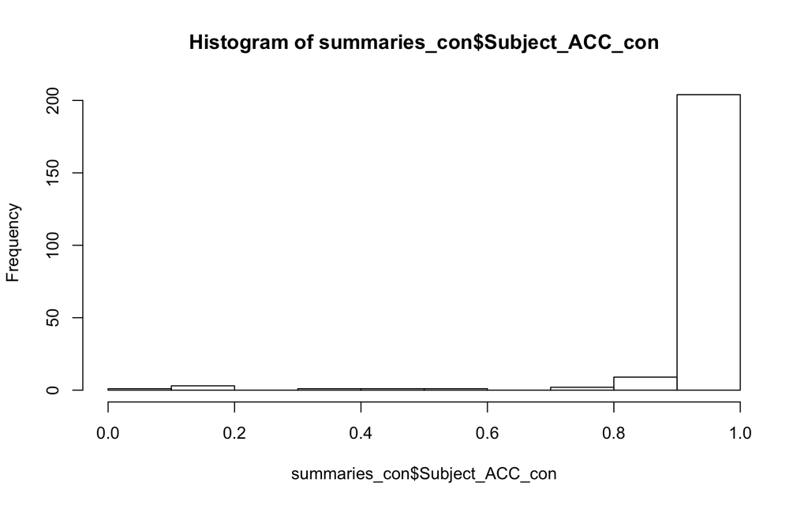

```r
summaries_tot <- flank %>% group_by(Subject) %>% summarise(Subject_ACC = as.numeric(table(TrialSlide_ACC)[2])/(as.numeric(table(TrialSlide_ACC)[2])+as.numeric(table(TrialSlide_ACC)[1])))
summaries_con <- flank %>% group_by(Subject, Incongruent)%>% summarise(Subject_ACC_con = as.numeric(table(TrialSlide_ACC)[2])/(as.numeric(table(TrialSlide_ACC)[2])+as.numeric(table(TrialSlide_ACC)[1])))



# commented to not muck up the makrdown but if interested can uncomment and run.

# for (i in which(is.na(summaries_tot$Subject_ACC))) {
#   df <- summaries_tot[i,]
#
#   sub <- df$Subject
#   # con <- df$Incongruent
#
#   s <- flank %>% filter(Subject == sub)
#   print(table(s[,c("TrialSlide_ACC")]))
#
#
# }
#
# for (i in which(is.na(summaries$Subject_ACC_con))) {
#   df <- summaries[i,]
#
#   sub <- df$Subject
#   con <- df$Incongruent
#
#   s <- flank %>% filter(Subject == sub)
#   print(table(s[,c("TrialSlide_ACC", "Incongruent")]))
#
#
# }

#appears to be driven by conditions where subjects were perfect (note the 0 in the congruent inaccurate cell, could be incongruent inaccurate cell or both. Manually set these to 1)
summaries_con$Subject_ACC_con[which(is.na(summaries_con$Subject_ACC_con))] <- 1
summaries_tot$Subject_ACC[which(is.na(summaries_tot$Subject_ACC))] <- 1

hist(summaries_con$Subject_ACC_con)
```

```r
problem_accs <- summaries_con %>% filter(Subject_ACC_con <= .6) %>% arrange(Subject_ACC_con) %>% print()
```

```
## # A tibble: 7 x 3
## # Groups:   Subject [7]
##   Subject Incongruent Subject_ACC_con
##     <dbl>       <dbl>           <dbl>
## 1      55           1          0.0641
## 2       7           1          0.111
## 3      83           1          0.118
## 4      47           1          0.180
## 5      14           1          0.304
## 6      62           1          0.478
## 7      38           1          0.512
```

```r
badsubs_cong <- unique(problem_accs$Subject)
```

3. Compute and display (as table) summary statistics for accuracy by subject and block.

```r
summaries_abba <- flank %>% group_by(Subject, ABBA) %>% summarise(Subject_ACC_abba = as.numeric(table(TrialSlide_ACC)[2])/(as.numeric(table(TrialSlide_ACC)[2])+as.numeric(table(TrialSlide_ACC)[1])))

summaries_abba$Subject_ACC_abba <- ifelse(is.na(summaries_abba$Subject_ACC_abba),1,summaries_abba$Subject_ACC_abba)
which(is.na(summaries_abba$Subject_ACC_con))
```

```
## integer(0)
```

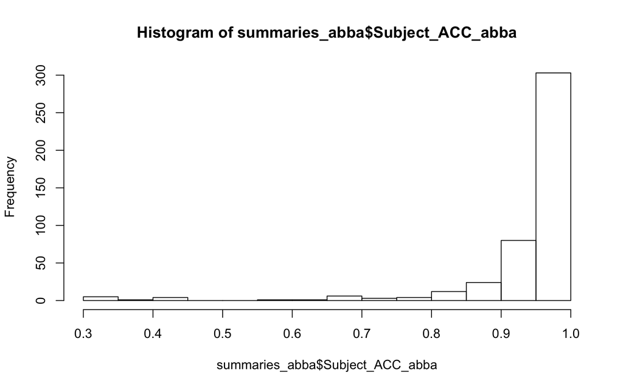

```r
hist(summaries_abba$Subject_ACC_abba)
```

```r
bad_blocks <- summaries_abba %>% filter(Subject_ACC_abba <= .6) %>% arrange(Subject_ACC_abba)
# print(bad_blocks)

badsubs_abba <- unique(bad_blocks$Subject)
badsubs_tot <- unique(c(badsubs_cong, badsubs_abba))  # subjects with either poor accuracy on a given block or on incongruent trials


badsubs_abba
```

```
## [1] 55  7 83 47 14 38
```

```r
badsubs_cong #adds 62, wonder
```

```
## [1] 55  7 83 47 14 62 38
```

```r
summaries_abba <- summaries_abba %>% mutate(Incongruent = ifelse(grepl("A",ABBA), 0,1)) %>% left_join(summaries_con, by = c("Subject", "Incongruent")) %>% left_join(summaries_tot, by = "Subject") #%>% arrange("Subject_ACC")
summaries_abba %>% filter(Subject %in% badsubs_tot)
```

```
## # A tibble: 28 x 6
## # Groups:   Subject [7]
##    Subject ABBA  Subject_ACC_abba Incongruent Subject_ACC_con Subject_ACC
##      <dbl> <chr>            <dbl>       <dbl>           <dbl>       <dbl>
##  1       7 A1               0.744           0           0.975       0.566
##  2       7 A2               0.784           0           0.975       0.566
##  3       7 B1               0.308           1           0.111       0.566
##  4       7 B2               0.432           1           0.111       0.566
##  5      14 A1               0.825           0           0.988       0.648
##  6      14 A2               0.875           0           0.988       0.648
##  7      14 B1               0.45            1           0.304       0.648
##  8      14 B2               0.436           1           0.304       0.648
##  9      38 A1               0.875           0           0.975       0.744
## 10      38 A2               0.825           0           0.975       0.744
## # … with 18 more rows
```

```r
# unclear why ABBA and congruent/incongruent split are so different. perhaps return to this later?
```

3.1 Are the bad subjects elevated on certain personality traits? If they are more trait impulsive, if they’re on the borderline there may be an argument for keeping them.

```r
if(create_plots){
  # png("Figures/bad_subject_SNAP_histograms.png")#, width = 11, height = 8)
  pdf("Figures/bad_subject_SNAP_histograms.pdf", width = 11, height = 8)
  for(s in names(SNAPz)[-1]){
    x <- SNAPz %>% filter(Subject %in% badsubs_tot) %>% na.omit()%>% select(s, "Subject")#%>% mutate(clr = letters[1:nrow(.)]) #%>% as.matrix() # 38 doesnt have SNAP
    x$Subject <- as.factor(x$Subject)
    x[,s] <- jitter(x[,s])
    p <- ggplot(SNAPz, aes_string(x = s)) + geom_histogram() + geom_vline(data = x, aes_string(xintercept = s, color = "Subject"), linetype = "dotted", size = 1)
    plot(p)
  }
  dev.off()
}
```

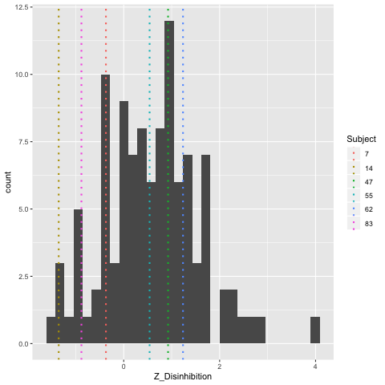

```r
knitr::include_graphics(path.expand("/Users/nth7/PD_Inhibition_DDM/Figures/bad_subject_SNAP_histograms.png")) ### this causes the knit to bomb, which is driving me mad.
```

```r
# exists("/Users/nth7/PD_Inhibition_DDM/Figures/bad_subject_SNAP_histograms.pdf") ## FALSE... -___-
# list.files("/Users/nth7/PD_Inhibition_DDM/Figures")
```

Long story short is that these folks seem to occupy well-populated portions of the distributions of SNAP variables. So it is probably fine to stay on the safe side and exclude all (7) of these folks.

```r
flank_acc_trim <- flank %>% filter(!Subject %in% badsubs_tot)
length(unique(flank_acc_trim$Subject))
```

```
## [1] 104
```

```r
#we lose 7 folks for being highly inaccurate on incongruent trials
```

4. Identify unbelievably fast RTs < 100ms. Recode both RT and accuracy to NA. Consider different options for long outliers (e.g. censoring vs winsorizing)

```r
# str(flank_acc_trim)
flank_acc_trim <- flank_acc_trim %>% rename(`rt` = `TrialSlide_RT`)

flank_acc_trim <- flank_acc_trim %>% mutate(group_Amean_rt = mean(rt, na.rm = TRUE),
                                            group_Hmean_rt = harmonic.mean(rt, na.rm = TRUE),
                                            group_SD_rt = sd(rt, na.rm = TRUE),) %>% mutate(group_SD3Amean_rt_high = group_Amean_rt + 3*group_SD_rt,
                                                                                            group_SD3Amean_rt_low = group_Amean_rt - 3*group_SD_rt,
                                                                                            group_SD3AHmean_rt_high = group_Hmean_rt + 3*group_SD_rt,
                                                                                            group_SD3AHmean_rt_low = group_Hmean_rt - 3*group_SD_rt) %>%
  group_by(Subject) %>% mutate(Amean_rt = mean(rt, na.rm = TRUE),
                               Hmean_rt = harmonic.mean(rt, na.rm = TRUE),
                               SD_rt = sd(rt, na.rm = TRUE),) %>% mutate(SD3Amean_rt_high = Amean_rt + 3*SD_rt,
                                                                         SD3Amean_rt_low = Amean_rt - 3*SD_rt,
                                                                         SD3AHmean_rt_high = Hmean_rt + 3*SD_rt,
                                                                         SD3AHmean_rt_low = Hmean_rt - 3*SD_rt) %>%
  group_by(Subject, Incongruent) %>% mutate(con_Amean_rt = mean(rt, na.rm = TRUE),
                                            con_Hmean_rt = harmonic.mean(rt, na.rm = TRUE),
                                            con_SD_rt = sd(rt, na.rm = TRUE),) %>% mutate(con_SD3Amean_rt_high = con_Amean_rt + 3*con_SD_rt,
                                                                                          con_SD3Amean_rt_low = con_Amean_rt - 3*con_SD_rt,
                                                                                          con_SD3AHmean_rt_high = con_Hmean_rt + 3*con_SD_rt,
                                                                                          con_SD3AHmean_rt_low = con_Hmean_rt - 3*con_SD_rt)

if(create_plots){
  pdf("Figures/subject_rt_dists_raw.pdf", width = 11, height = 8)

  #plot group first
  x <- ggplot(flank_acc_trim, aes(x = rt)) + geom_histogram() +
    geom_vline(xintercept = unique(flank_acc_trim$group_Hmean_rt)) +
    geom_vline(xintercept = unique(flank_acc_trim$group_SD3AHmean_rt_low), color = "red") +
    geom_vline(xintercept = unique(flank_acc_trim$group_SD3AHmean_rt_high), color = "red") + xlim(0,1000) +
    labs(title = "Harmonic mean and 3 SD over/under, whole group")

  y <- ggplot(flank_acc_trim, aes(x = rt)) + geom_histogram() +
    geom_vline(xintercept = unique(flank_acc_trim$group_Amean_rt)) +
    geom_vline(xintercept = unique(flank_acc_trim$group_SD3Amean_rt_low), color = "red") +
    geom_vline(xintercept = unique(flank_acc_trim$group_SD3Amean_rt_high), color = "red") + xlim(0,1000) +
    labs(title = "Arithmetic mean and 3 SD over/under, whole group")

  plot_grid(x,y, ncol = 1)
  for(s in unique(flank_acc_trim$Subject)){
    df <- flank_acc_trim %>% filter(Subject == s)
    dfi <- filter(df, Incongruent == 1); dfc <- filter(df, Incongruent == 0)

    x_low <- max(0,min((unique(df$SD3AHmean_rt_low)-50), (unique(df$SD3Amean_rt_low) -50), (range(df$rt, na.rm = TRUE)[1]) - 50))
    x_high <- min(1000,max((unique(df$SD3AHmean_rt_high)+50), (unique(df$SD3Amean_rt_high) +50), (range(df$rt, na.rm = TRUE)[2]) + 50))


    by_sub_harm <- ggplot(df, aes(x = rt)) + geom_histogram(bins = 40) +
      geom_vline(xintercept = unique(dfc$group_Amean_rt), color = "black", linetype = "dotted") +
      geom_vline(xintercept = unique(df$group_SD3Amean_rt_low), color = "black", linetype = "dotted") +
      geom_vline(xintercept = unique(df$group_SD3Amean_rt_high), color = "black", linetype = "dotted") +
      geom_vline(xintercept = unique(df$Hmean_rt), color = "red") +
      geom_vline(xintercept = unique(df$SD3AHmean_rt_low), color = "red") +
      geom_vline(xintercept = unique(df$SD3AHmean_rt_high), color = "red") + xlim(x_low, x_high) +
      labs(title = paste0("Subject ",s),subtitle = "Harmonic mean and 3 SD over/under, per subject")
    # plot(x)

    by_sub_art <- ggplot(df, aes(x = rt)) + geom_histogram(bins = 40) +
      geom_vline(xintercept = unique(df$Amean_rt)) +
      geom_vline(xintercept = unique(df$SD3Amean_rt_low), color = "red") +
      geom_vline(xintercept = unique(df$SD3Amean_rt_high), color = "red") +
      geom_vline(xintercept = unique(dfc$group_Amean_rt), color = "black", linetype = "dotted") +
      geom_vline(xintercept = unique(df$group_SD3Amean_rt_low), color = "black", linetype = "dotted") +
      geom_vline(xintercept = unique(df$group_SD3Amean_rt_high), color = "black", linetype = "dotted") + xlim(x_low, x_high) +
      labs(title = paste0("Subject ",s),subtitle = "Arimetic mean and 3 SD over/under, per subject")

    by_sub_incon_harm <- ggplot(dfi, aes(x = rt)) + geom_histogram(bins = 40) +
      geom_vline(xintercept = unique(dfi$Hmean_rt), color = "gray", linetype = "dotted") +
      geom_vline(xintercept = unique(df$SD3AHmean_rt_low), color = "gray", linetype = "dotted") +
      geom_vline(xintercept = unique(df$SD3AHmean_rt_high), color = "gray", linetype = "dotted") +
      geom_vline(xintercept = unique(dfc$group_Amean_rt), color = "black", linetype = "dotted") +
      geom_vline(xintercept = unique(df$group_SD3Amean_rt_low), color = "black", linetype = "dotted") +
      geom_vline(xintercept = unique(df$group_SD3Amean_rt_high), color = "black", linetype = "dotted") +
      geom_vline(xintercept = unique(dfi$con_Hmean_rt), color = "red") +
      geom_vline(xintercept = unique(dfi$con_SD3AHmean_rt_low), color = "red") +
      geom_vline(xintercept = unique(dfi$con_SD3AHmean_rt_high), color = "red") + xlim(x_low, x_high) +
      labs(title = paste0("Subject ",s, " incongruent trials"),subtitle = "Harmonic mean and 3 SD over/under, per subjectfor ONLY incongruent trials")

    by_sub_incon_art <- ggplot(dfi, aes(x = rt)) + geom_histogram(bins = 40) +
      geom_vline(xintercept = unique(dfi$Amean_rt), color = "gray", linetype = "dotted") +
      geom_vline(xintercept = unique(df$SD3Amean_rt_low), color = "gray", linetype = "dotted") +
      geom_vline(xintercept = unique(df$SD3Amean_rt_high), color = "gray", linetype = "dotted") +
      geom_vline(xintercept = unique(dfc$group_Amean_rt), color = "black", linetype = "dotted") +
      geom_vline(xintercept = unique(df$group_SD3Amean_rt_low), color = "black", linetype = "dotted") +
      geom_vline(xintercept = unique(df$group_SD3Amean_rt_high), color = "black", linetype = "dotted") +
      geom_vline(xintercept = unique(dfi$con_Amean_rt), color = "red") +
      geom_vline(xintercept = unique(dfi$con_SD3Amean_rt_low), color = "red") +
      geom_vline(xintercept = unique(dfi$con_SD3Amean_rt_high), color = "red") + xlim(x_low, x_high) +
      labs(title = paste0("Subject ",s, " incongruent trials"),subtitle = "Arithmetic mean and 3 SD over/under, per subject for ONLY incongruent trials")


    by_sub_con_harm <- ggplot(dfc, aes(x = rt)) + geom_histogram(bins = 40) +
      geom_vline(xintercept = unique(dfc$Hmean_rt), color = "gray", linetype = "dotted") +
      geom_vline(xintercept = unique(df$SD3AHmean_rt_low), color = "gray", linetype = "dotted") +
      geom_vline(xintercept = unique(df$SD3AHmean_rt_high), color = "gray", linetype = "dotted") +
      geom_vline(xintercept = unique(dfc$group_Amean_rt), color = "black", linetype = "dotted") +
      geom_vline(xintercept = unique(df$group_SD3Amean_rt_low), color = "black", linetype = "dotted") +
      geom_vline(xintercept = unique(df$group_SD3Amean_rt_high), color = "black", linetype = "dotted") +
      geom_vline(xintercept = unique(dfc$con_Hmean_rt), color = "red") +
      geom_vline(xintercept = unique(dfc$con_SD3AHmean_rt_low), color = "red") +
      geom_vline(xintercept = unique(dfc$con_SD3AHmean_rt_high), color = "red") + xlim(x_low, x_high) +
      labs(title = paste0("Subject ",s, " congruent trials"),subtitle = "Harmonic mean and 3 SD over/under, per subject for ONLY congruent trials")

    by_sub_con_art <- ggplot(dfc, aes(x = rt)) + geom_histogram(bins = 40) +
      geom_vline(xintercept = unique(dfc$Amean_rt), color = "gray", linetype = "dotted") +
      geom_vline(xintercept = unique(df$SD3Amean_rt_low), color = "gray", linetype = "dotted") +
      geom_vline(xintercept = unique(df$SD3Amean_rt_high), color = "gray", linetype = "dotted") +
      geom_vline(xintercept = unique(dfc$group_Amean_rt), color = "black", linetype = "dotted") +
      geom_vline(xintercept = unique(df$group_SD3Amean_rt_low), color = "black", linetype = "dotted") +
      geom_vline(xintercept = unique(df$group_SD3Amean_rt_high), color = "black", linetype = "dotted") +
      geom_vline(xintercept = unique(dfc$con_Amean_rt), color = "red") +
      geom_vline(xintercept = unique(dfc$con_SD3Amean_rt_low), color = "red") +
      geom_vline(xintercept = unique(dfc$con_SD3Amean_rt_high), color = "red") + xlim(x_low, x_high) +
      labs(title = paste0("Subject ",s, " congruent trials"),subtitle = "Arithmetic mean and 3 SD over/under, per subject for ONLY congruent trials")


    x <- plot_grid(by_sub_harm,  by_sub_con_harm, by_sub_incon_harm,by_sub_art,by_sub_con_art,  by_sub_incon_art)
    plot(x)

  }
  dev.off()
}

# different papers use different cutoff values e.g:
# Dillon et al (2015): 150 or if the log-transformed RT exceeded the participant’s mean ± 3S.D., computed separately for congruent and incongruent stimuli
# Grange & Rydon-Grange (preprint): 250 and 1500

range(flank_acc_trim$rt,na.rm = TRUE) # my hunch is that NA trials are timeouts where the subject did not respond within 1000 msec.
```

```
## [1] 161 970
```

```r
quantile(flank_acc_trim$rt, na.rm = TRUE, probs = c(0,.05,.1, .9, .95,.99,1))
```

```
##   0%   5%  10%  90%  95%  99% 100%
##  161  285  304  488  545  682  970
```

```r
perc.rank <- function(x, xo)  length(x[x <= xo])/length(x)*100
perc.rank(flank_acc_trim$rt, 700)
```

```
## [1] 99.19471
```

```r
perc.rank(flank_acc_trim$rt, 250)
```

```
## [1] 1.808894
```

5. Compute and display (as table) summary statistics for RT by subject and block. May need to leverage harmonic mean (Ratcliff) or ex-Gaussian fitted statistics to get a sense of averages (given positive skew of RTs).
6. Screen for excessively long RTs. Divide dataset by subject and use distribution of RTs within subject as benchmark for “long” (e.g., 1.5 * IQR above 75th %ile). Recode to NA or potentially Winsorize.
7. Screen for unlikely RT means between subjects, separating incongruent and congruent trials. For example, if the congruent sample average is ~250ms and one subject has a mean ~750ms, is this plausible? If not, discuss and potentially drop.
8. Check for subjects with a high number of NA trials. Could be due to RTs and accuracies that are not properly recorded (NA), or could be an unbelievably fast outlier. Consider removing subjects with a high number of NAs in conjunction with results from 2.1

```r
# data.frame(flanker[which(is.na(flanker$TrialSlide_ACC)),"Flanker"]) == data.frame(flanker[which(is.na(flanker$TrialSlide_RT)),"Flanker"]) #looks like these are the same.

x <- data.frame(flanker[which(is.na(flanker$TrialSlide_ACC)),])
sort(table(x$Subject))  ##worst offender has 25/160 or .15625 of trials with an NA RT or ACC.
```

```
##
##  14  18  21  22  27  32  33  34  57  58  68  82  99 102 105 113  15  24  46  55
##   1   1   1   1   1   1   1   1   1   1   1   1   1   1   1   1   2   2   2   2
##  89 109  42  65  90  83 110  35  45  73   7  36  92  62  47
##   2   2   3   3   3   4   4   5   6   6   8  11  12  19  25
```

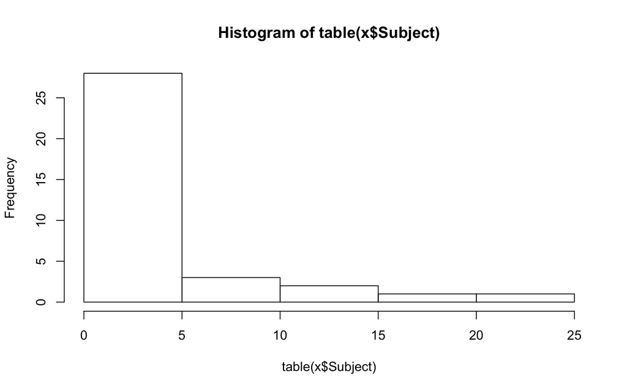

```r
hist(table(x$Subject))
```

```r
flank_na.rm <- flank[-which(is.na(flank$TrialSlide_ACC)),]

# table(flank_na.rm$Block)
# length(table(flank_na.rm$Block))
# length(unique(flank_na.rm$Subject))
sort(table(flank_na.rm$Subject))
```

```
##
##  47  62  92  36   7  45  73  35  83 110  42  65  90  15  24  46  55  89 109  14
## 135 141 148 149 152 154 154 155 156 156 157 157 157 158 158 158 158 158 158 159
##  18  21  22  27  32  33  34  57  58  68  82  99 102 105 113   1   2   3   4   5
## 159 159 159 159 159 159 159 159 159 159 159 159 159 159 159 160 160 160 160 160
##   6   8   9  10  11  12  13  16  17  19  20  23  25  26  28  29  30  31  37  38
## 160 160 160 160 160 160 160 160 160 160 160 160 160 160 160 160 160 160 160 160
##  40  41  43  48  49  50  51  52  53  54  56  59  60  61  63  64  66  67  69  70
## 160 160 160 160 160 160 160 160 160 160 160 160 160 160 160 160 160 160 160 160
##  71  72  74  75  76  77  78  79  81  84  85  86  87  88  91  93  94  95  96  97
## 160 160 160 160 160 160 160 160 160 160 160 160 160 160 160 160 160 160 160 160
##  98 100 101 103 104 106 107 108 111 112 114
## 160 160 160 160 160 160 160 160 160 160 160
```

```r
#looks like 47 and 62 are the most concerning, perhaps falling asleep/ not paying attention?
```

## Basic multilevel modeling of flanker data

Once these steps are complete, use `lme4::lmer` and `lme4::glmer` to model RTs and accuracies, respectively. The model will contain a random intercept per subject `(1 | Subject)` reflecting trials nested within subject. There may be fixed or random linear effects of trial, which would reflect gradual speeding or slowing of RTs or improvement/degradation of accuracy. Residual covariance structures such as AR(1) or compound symmetry may also be considered using the `nlme::lme` function. Something like:

```r
lme(RT ~ trial + Incongruent*CongruentBlock, random = ~ 1 | Subject,
    correlation=corCompSymm(form=~trial|person), na.action = na.exclude,
    data = flanker,method='REML'))
```

Use likelihood ratio tests (typically `anova` on `lmer` objects) to adjudicate best fit.

## HDDM

Once the MLMs and GLMMs are understood, move onto HDDM. :)